# EE624: Speech Technology

## DTW-Based Isolated Vowel Recognition

# Submitted by - Faisal ziyad Ahmed (254102311)

Project 1: Perform DTW based isolated vowel recognition

• Record twenty five utterances of each of the isolated English digits (0-9), vowels (a,e,i,o,u),  
and the given sentence (I'm registered with speech technology course and recording this data for the course project) in your voice. Record speech data over PC using Audacity software in PCM format with a sampling frequency of 16 kHz and a precision of 16-bits. Store the  
recorded data as: <Roll.No>*//sentence*<recording_num>.wav. Human voice characteristics usually differ slightly over the time and it is referred to as the session  
variation. So you are advised to record different entities at least in two sessions.

• For each of the vowels, choose one of the utterance as the reference template and the  
remaining ones as the test templates. Compute 39-dimensional MFCC features comprising base, delta, and delta-delta components for all the recordings using MATLAB. Using DTW  
command of MATLAB, write a script that computes DTW scores for any two similar or  
dissimilar test utterances and also plots the corresponding DTW curve

```python
pip install dtw-python
```

### Imports

```python
import os
import numpy as np
import librosa
import matplotlib.pyplot as plt
from scipy.spatial.distance import cdist
from sklearn.metrics import confusion_matrix, accuracy_score
import seaborn as sns
```

### Configuration

**Fix:** `VOWELS` now matches the actual folder names (`A, E, I, O, U` uppercase).  
The old code had lowercase `['a','e','i','o','u']` which caused a mismatch with the folders.

```python
DATASET_PATH = r"C:\Users\DELL\OneDrive\Desktop\Instructional materials\Speech technology\Project\Vowel"

# FIX: uppercase to match actual folder names A/ E/ I/ O/ U/
VOWELS = ['A', 'E', 'I', 'O', 'U']

SR     = 16000
N_MFCC = 13
```

### Feature Extraction (39-dim MFCC)

```python
def extract_features(file_path):
    """Load a wav file and return 39-dim MFCC matrix of shape (T, 39)."""
    y, sr = librosa.load(file_path, sr=SR)
    y, _  = librosa.effects.trim(y)   # remove leading/trailing silence

    mfcc   = librosa.feature.mfcc(y=y, sr=sr, n_mfcc=N_MFCC)
    delta  = librosa.feature.delta(mfcc)
    delta2 = librosa.feature.delta(mfcc, order=2)

    features = np.vstack((mfcc, delta, delta2))  # (39, T)
    return features.T                             # (T, 39)
```

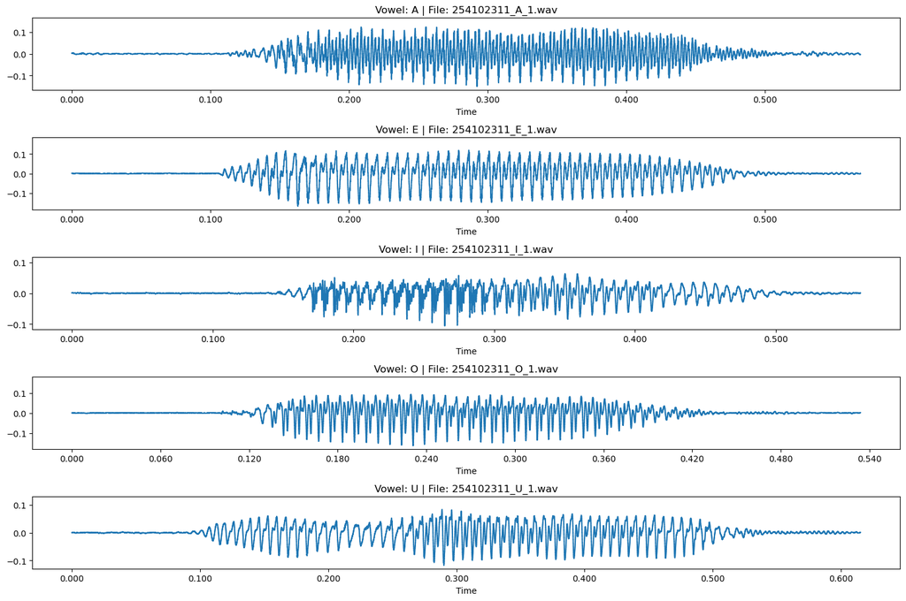

```python
base_path = r"C:\Users\DELL\OneDrive\Desktop\Instructional materials\Speech technology\Project\Vowel"

vowels = ["A", "E", "I", "O", "U"]

plt.figure(figsize=(15, 10))

plot_idx = 1

for vowel in vowels:
    folder_path = os.path.join(base_path, vowel)

    for file in os.listdir(folder_path):
        if file.endswith(".wav"):
            file_path = os.path.join(folder_path, file)

            audio, sr = librosa.load(file_path, sr=None)

            plt.subplot(len(vowels), 1, plot_idx)
            librosa.display.waveshow(audio, sr=sr)
            plt.title(f"Vowel: {vowel} | File: {file}")

            plot_idx += 1
            break   # remove this if you want ALL files per vowel

plt.tight_layout()
plt.show()
```

### DTW Computation

```python
def compute_dtw(ref, test):
    """
    Compute DTW between two MFCC sequences.
    Returns:
        score      : normalized DTW distance (total cost / path length)
        D          : accumulated cost matrix
        path       : optimal warping path as list of (i, j) tuples
    """
    distance_matrix = cdist(ref, test, metric='euclidean')
    D = np.zeros_like(distance_matrix)

    D[0, 0] = distance_matrix[0, 0]

    for i in range(1, D.shape[0]):
        D[i, 0] = distance_matrix[i, 0] + D[i-1, 0]

    for j in range(1, D.shape[1]):
        D[0, j] = distance_matrix[0, j] + D[0, j-1]

    for i in range(1, D.shape[0]):
        for j in range(1, D.shape[1]):
            D[i, j] = distance_matrix[i, j] + min(
                D[i-1, j],
                D[i, j-1],
                D[i-1, j-1]
            )

    # ── Backtracking to recover optimal path ──
    i, j = D.shape[0] - 1, D.shape[1] - 1
    path = [(i, j)]

    while i > 0 and j > 0:
        steps = [D[i-1, j], D[i, j-1], D[i-1, j-1]]
        move  = np.argmin(steps)
        if move == 0:
            i -= 1
        elif move == 1:
            j -= 1
        else:
            i -= 1
            j -= 1
        path.append((i, j))

    path.reverse()

    # FIX: normalize by path length so scores are comparable across
    # pairs of different durations (raw score was in the thousands)
    normalized_score = D[-1, -1] / len(path)

    return normalized_score, D, path
```

### Plot DTW Curve

This is the function the project asks you to plot: the cost matrix with the optimal warping path overlaid.

```python
def plot_dtw(D, path, title="DTW Alignment"):
    """
    Plot the DTW accumulated cost matrix and the optimal warping path.
    D    : accumulated cost matrix  (shape: T_ref x T_test)
    path : list of (i, j) index tuples — the optimal warping path
    """
    path_i = [p[0] for p in path]
    path_j = [p[1] for p in path]

    plt.figure(figsize=(7, 5))
    plt.imshow(D, origin='lower', aspect='auto', cmap='viridis')
    plt.colorbar(label='Accumulated Cost')
    plt.plot(path_j, path_i, color='red', linewidth=2, label='Warping Path')
    plt.xlabel('Test Utterance Frames')
    plt.ylabel('Reference Utterance Frames')
    plt.title(title)
    plt.legend(loc='upper left')
    plt.tight_layout()
    plt.show()
```

### Compare Similar Vowel Pairs (same vowel, different utterances)

```
===================================
Comparing A vs A  (similar)
Normalized DTW Score: 63.6350
```

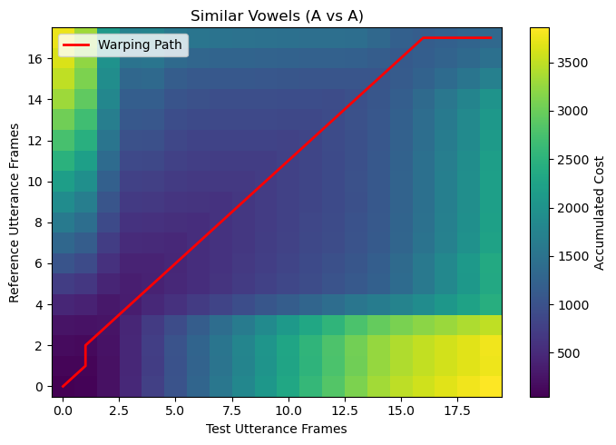

```
===================================
Comparing E vs E  (similar)
Normalized DTW Score: 58.0740
```

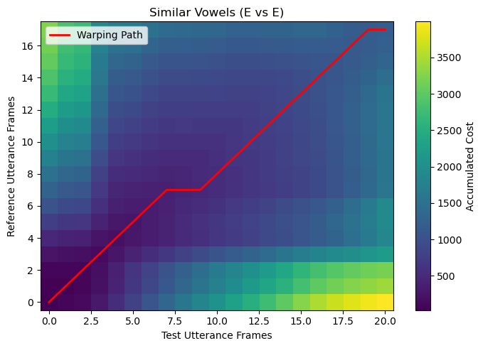

```
===================================
Comparing I vs I  (similar)
Normalized DTW Score: 73.9456
```

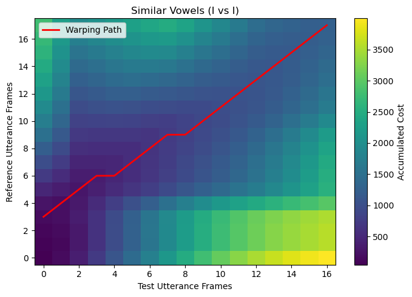

```
===================================
Comparing O vs O  (similar)
Normalized DTW Score: 52.9660
```

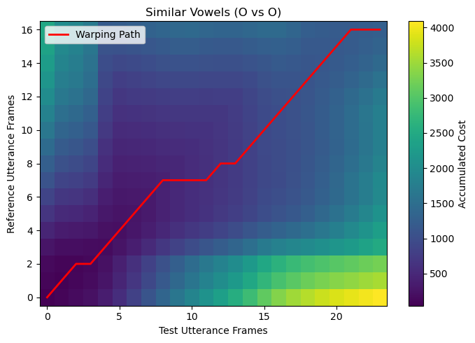

```
===================================
Comparing U vs U  (similar)
Normalized DTW Score: 36.4941
```

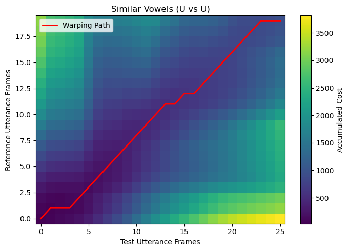

```python
# Your file naming: 254102311_A_1.wav, 254102311_A_20.wav, etc.
base_path = DATASET_PATH

similar_scores = []

for folder_name in VOWELS:
    file1 = os.path.join(base_path, folder_name, f"254102311_{folder_name}_1.wav")
    file2 = os.path.join(base_path, folder_name, f"254102311_{folder_name}_20.wav")

    print("\n" + "="*35)
    print(f"Comparing {folder_name} vs {folder_name}  (similar)")

    f1 = extract_features(file1)
    f2 = extract_features(file2)

    score, D, path = compute_dtw(f1, f2)
    similar_scores.append(score)

    print(f"Normalized DTW Score: {score:.4f}")

    # FIX: plot_dtw is now defined above — no more NameError
    plot_dtw(D, path, f"Similar Vowels ({folder_name} vs {folder_name})")
```

### Compare Dissimilar Vowel Pairs (different vowels)

```
===================================
Comparing A vs E  (dissimilar)
Normalized DTW Score: 82.5863
```

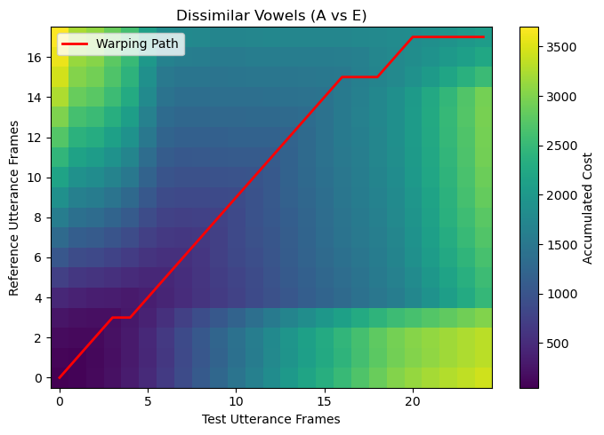

```
===================================
Comparing A vs I  (dissimilar)
Normalized DTW Score: 115.5647
```

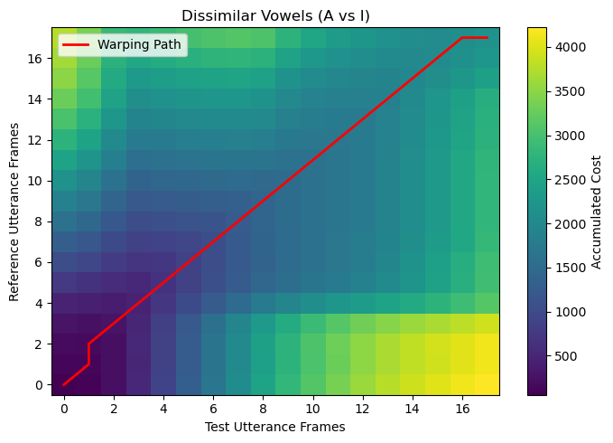

```
===================================
Comparing A vs O  (dissimilar)
Normalized DTW Score: 116.3768
```

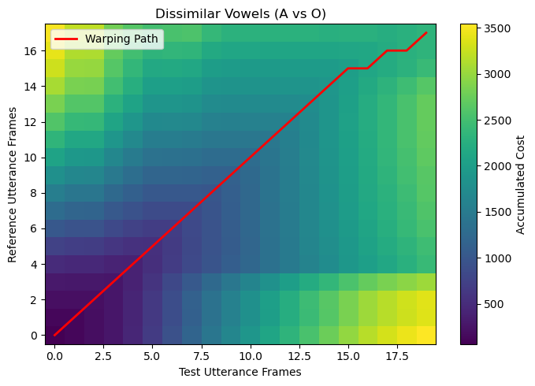

```
===================================
Comparing A vs U  (dissimilar)
Normalized DTW Score: 92.9916
```

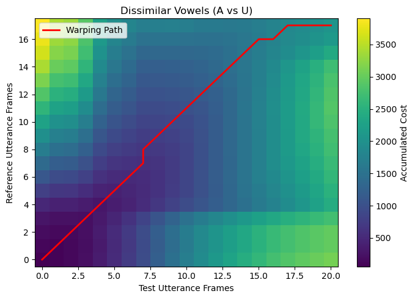

```python
pairs = [('A','E'), ('A','I'), ('A','O'), ('A','U')]

dissimilar_scores = []

for p1, p2 in pairs:
    file1 = os.path.join(base_path, p1, f"254102311_{p1}_1.wav")
    file2 = os.path.join(base_path, p2, f"254102311_{p2}_21.wav")

    print("\n" + "="*35)
    print(f"Comparing {p1} vs {p2}  (dissimilar)")

    f1 = extract_features(file1)
    f2 = extract_features(file2)

    score, D, path = compute_dtw(f1, f2)
    dissimilar_scores.append(score)

    print(f"Normalized DTW Score: {score:.4f}")

    plot_dtw(D, path, f"Dissimilar Vowels ({p1} vs {p2})")
```

### Bar Chart: Similar vs Dissimilar DTW Scores

This makes it visually clear that same-vowel pairs score lower (more similar) than different-vowel pairs.

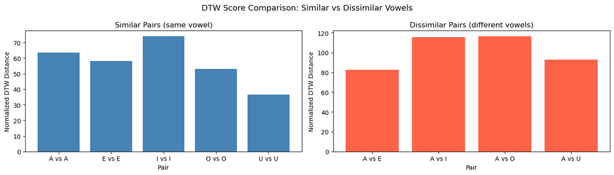

```
Average similar score    : 57.0229
Average dissimilar score : 101.8799
→ Dissimilar should be larger (worse match)
```

```python
similar_labels    = [f"{v} vs {v}" for v in VOWELS]
dissimilar_labels = [f"{p1} vs {p2}" for p1, p2 in pairs]

x  = np.arange(max(len(similar_scores), len(dissimilar_scores)))

fig, axes = plt.subplots(1, 2, figsize=(14, 4))

axes[0].bar(similar_labels, similar_scores, color='steelblue')
axes[0].set_title('Similar Pairs (same vowel)')
axes[0].set_ylabel('Normalized DTW Distance')
axes[0].set_xlabel('Pair')

axes[1].bar(dissimilar_labels, dissimilar_scores, color='tomato')
axes[1].set_title('Dissimilar Pairs (different vowels)')
axes[1].set_ylabel('Normalized DTW Distance')
axes[1].set_xlabel('Pair')

plt.suptitle('DTW Score Comparison: Similar vs Dissimilar Vowels', fontsize=13)
plt.tight_layout()
plt.show()

print(f"\nAverage similar score    : {np.mean(similar_scores):.4f}")
print(f"Average dissimilar score : {np.mean(dissimilar_scores):.4f}")
print("→ Dissimilar should be larger (worse match)")
```

```python
import pandas as pd
import numpy as np

# Combine labels and scores
all_labels = similar_labels + dissimilar_labels
all_scores = similar_scores + dissimilar_scores
types = ["Similar"] * len(similar_scores) + ["Dissimilar"] * len(dissimilar_scores)

# Create DataFrame
dtw_table = pd.DataFrame({
    "Comparison": all_labels,
    "Type": types,
    "Normalized DTW Score": all_scores
})

# Sort (optional)
dtw_table = dtw_table.sort_values(by="Normalized DTW Score")

print("\nDTW Score Table:\n")
print(dtw_table.to_string(index=False))

dtw_table
```

```
DTW Score Table:

Comparison       Type  Normalized DTW Score
    U vs U    Similar             36.494094
    O vs O    Similar             52.965962
    E vs E    Similar             58.073953
    A vs A    Similar             63.635023
    I vs I    Similar             73.945575
    A vs E Dissimilar             82.586350
    A vs U Dissimilar             92.991629
    A vs I Dissimilar            115.564675
    A vs O Dissimilar            116.376751
```

|  | Comparison | Type | Normalized DTW Score |
| --- | --- | --- | --- |
| 4 | U vs U | Similar | 36.494094 |
| 3 | O vs O | Similar | 52.965962 |
| 1 | E vs E | Similar | 58.073953 |
| 0 | A vs A | Similar | 63.635023 |
| 2 | I vs I | Similar | 73.945575 |
| 5 | A vs E | Dissimilar | 82.586350 |
| 8 | A vs U | Dissimilar | 92.991629 |
| 6 | A vs I | Dissimilar | 115.564675 |
| 7 | A vs O | Dissimilar | 116.376751 |

### Build Reference Templates

```python
def build_references():
    """Use the first (sorted) file of each vowel folder as the reference template."""
    references = {}
    for vowel in VOWELS:                                       # VOWELS is now uppercase
        folder = os.path.join(DATASET_PATH, vowel)            # correctly finds A/ E/ etc.
        files  = sorted([f for f in os.listdir(folder) if f.endswith('.wav')])
        references[vowel] = extract_features(os.path.join(folder, files[0]))
        print(f"  Reference for '{vowel}': {files[0]}")
    return references
```

### Recognition Function

```python
def run_recognition():
    """
    For each vowel folder, skip the reference file (index 0) and
    classify the remaining 24 utterances by minimum DTW distance.
    """
    references = build_references()
    y_true = []
    y_pred = []

    for true_vowel in VOWELS:
        folder = os.path.join(DATASET_PATH, true_vowel)
        files  = sorted([f for f in os.listdir(folder) if f.endswith('.wav')])[1:]  # skip reference

        for file in files:
            test = extract_features(os.path.join(folder, file))

            # Score against all 5 reference templates
            scores = {}
            for ref_vowel in VOWELS:
                score, _, _ = compute_dtw(references[ref_vowel], test)
                scores[ref_vowel] = score

            prediction = min(scores, key=scores.get)   # nearest neighbour

            y_true.append(true_vowel)
            y_pred.append(prediction)

    return y_true, y_pred
```

### Run Evaluation & Plot Confusion Matrix

```
Running recognition on all utterances
  Reference for 'A': 254102311_A_1.wav
  Reference for 'E': 254102311_E_1.wav
  Reference for 'I': 254102311_I_1.wav
  Reference for 'O': 254102311_O_1.wav
  Reference for 'U': 254102311_U_1.wav

Recognition Accuracy: 90.83%
```

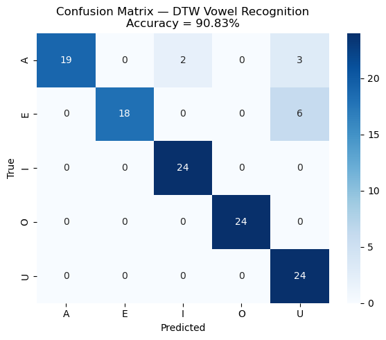

```python
print("Running recognition on all utterances")
y_true, y_pred = run_recognition()

cm  = confusion_matrix(y_true, y_pred, labels=VOWELS)
acc = accuracy_score(y_true, y_pred)

print(f"\nRecognition Accuracy: {acc * 100:.2f}%")

plt.figure(figsize=(6, 5))
sns.heatmap(cm, annot=True, fmt='d',
            xticklabels=VOWELS,
            yticklabels=VOWELS,
            cmap='Blues')
plt.xlabel('Predicted')
plt.ylabel('True')
plt.title(f'Confusion Matrix — DTW Vowel Recognition\nAccuracy = {acc*100:.2f}%')
plt.tight_layout()
plt.show()
```